# Tree Data Structure

Struktur Data Tree adalah struktur data non-linier di mana kumpulan elemen yang dikenal sebagai node terhubung satu sama lain melalui edge sedemikian rupa sehingga terdapat tepat satu jalur antara dua node mana pun.

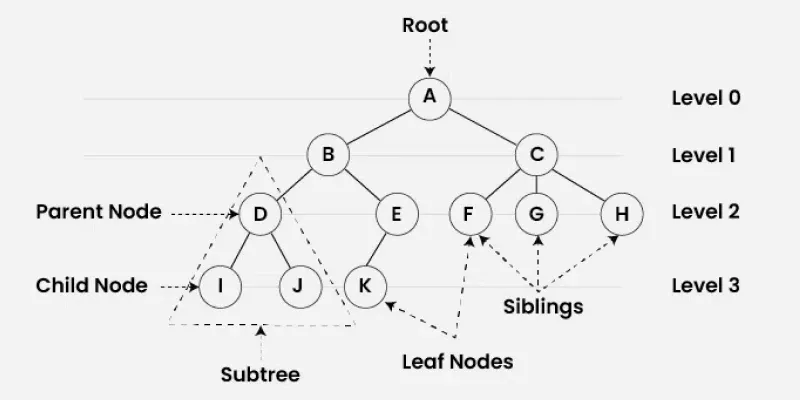

Tree adalah struktur data hierarkis yang digunakan untuk mengatur dan merepresentasikan data dalam hubungan induk-anak . Tree terdiri dari simpul-simpul, di mana simpul teratas disebut akar , dan setiap simpul lainnya dapat memiliki satu atau lebih simpul anak .

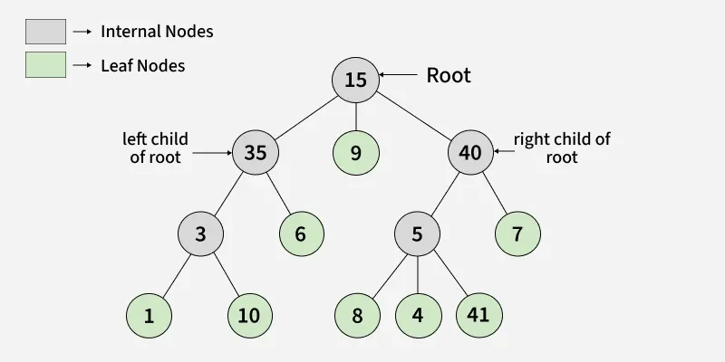

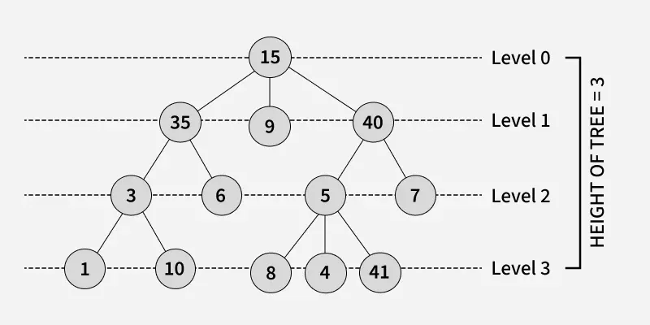

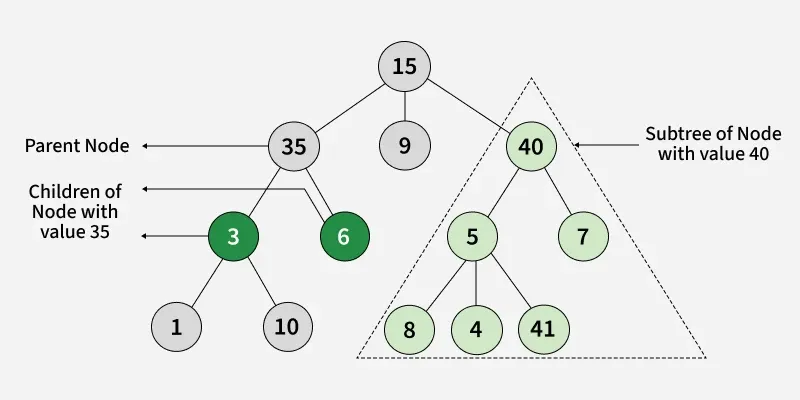

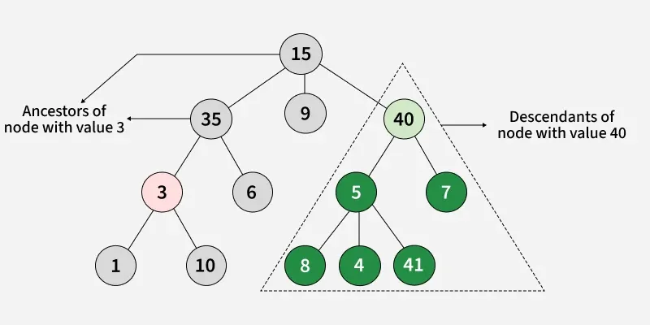

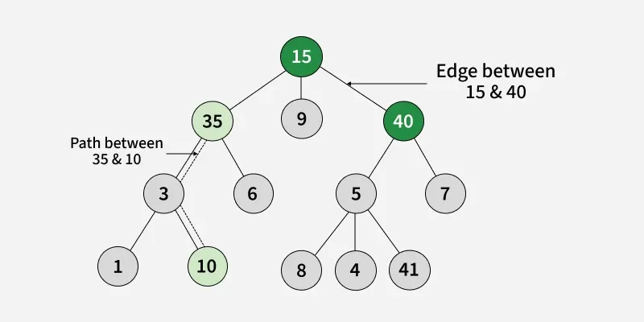